# mapster basics

## Intro

```r
library(mapster)
```

The package contains some custom functions to facilitate quick plotting 2d globe projections (lines, etc).

## Data

The information that is printed must be suplied in a dataframe. Also the attributes (e.g. `cex`) must be supplied as columns in the dataframe. The information can be supplied as 3d cartesian, spherical coordinates (lattitude and longitude) or projected user coordinates. As an example, we will use the endpoints of the standard cartesian axes.

```r
x <- data.frame(x=c(1, 0, 0, -1, 0, 0),
                y=c(0, 1, 0, 0, -1, 0),
                z=c(0, 0, 1, 0, 0, -1))
rownames(x) <- c("X+", "Y+", "Z+", "X-", "Y-", "Z-")
x
```

```
#>     x  y  z
#> X+  1  0  0
#> Y+  0  1  0
#> Z+  0  0  1
#> X- -1  0  0
#> Y-  0 -1  0
#> Z-  0  0 -1
```

First, a projection has to be set. This can be done using `map_proj`. Several presets are available.

```r
map_proj(preset="ortho")  # use presets and set before projecting
```

Calling `map_data` will look which type of coordinates are available and add the missing ones basd on the given projection method.

```r
s <- map_data(x, preset="ortho")
s
```

```
#>     x  y  z phi theta r            xp            yp
#> X+  1  0  0   0     0 1  0.000000e+00  0.000000e+00
#> Y+  0  1  0  90     0 1  1.000000e+00 -6.123234e-17
#> Z+  0  0  1   0    90 1  1.224647e-16  1.000000e+00
#> X- -1  0  0 180     0 1            NA            NA
#> Y-  0 -1  0 -90     0 1 -1.000000e+00 -6.123234e-17
#> Z-  0  0 -1   0   -90 1  0.000000e+00 -1.000000e+00
```

Additional information for each point can be supplied, that is used by the functions.

```r
s$label <- rownames(s)
s$col <- rep(c("darkgreen", "red"), each=3)
s$cex <- 1
s
```

```
#>     x  y  z phi theta r            xp            yp label       col cex
#> X+  1  0  0   0     0 1  0.000000e+00  0.000000e+00    X+ darkgreen   1
#> Y+  0  1  0  90     0 1  1.000000e+00 -6.123234e-17    Y+ darkgreen   1
#> Z+  0  0  1   0    90 1  1.224647e-16  1.000000e+00    Z+ darkgreen   1
#> X- -1  0  0 180     0 1            NA            NA    X-       red   1
#> Y-  0 -1  0 -90     0 1 -1.000000e+00 -6.123234e-17    Y-       red   1
#> Z-  0  0 -1   0   -90 1  0.000000e+00 -1.000000e+00    Z-       red   1
```

Now the data is ready for visualization.

## Visualizations

### Orthographic projection

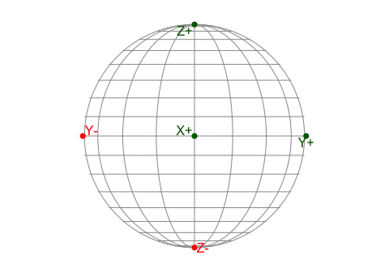

```r
par(mar=rep(1,4))
map_setup(s)
map_grid()
map_points(s)
map_labels(s)
```

### Mollweide projection

Choose type of projection and modify some arguments by hand.

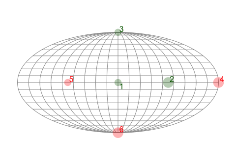

```r
par(mar=rep(1,4))
map_proj("mollweide")  # set projection type
s <- map_data(s)       # recalculate data, can usually be omitted
map_setup(s)
map_grid()
map_points(s, cex=2:3, col=scales::alpha(s$col, .3))
map_labels(s, label=1:6)
```

## More exampels

### Different presets

Create random data

```r
set.seed(0)
x <- random_data(20)
x$cex <- .7
```

Mollweide projection with some lines between points.

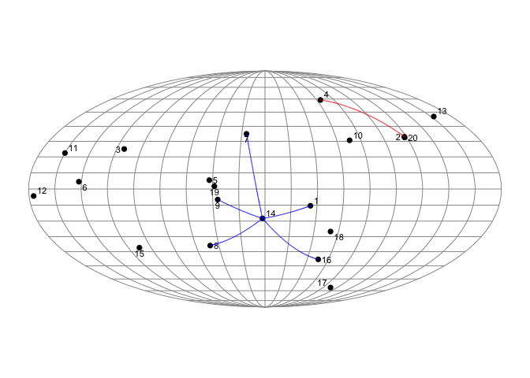

```r
par(mar=rep(1,4))
map_proj("mollweide")  # use presets and set before projecting
x <- map_data(x)
map_setup(x)
map_grid()
map_points(x, col="black", cex=1)
map_labels(x)
map_lines(x[4, ], x[2, ], col="red")
map_lines(x[c(1,7,8,9,16), ], x[14, ], col="blue")
```

Two more projection types (see for more types).

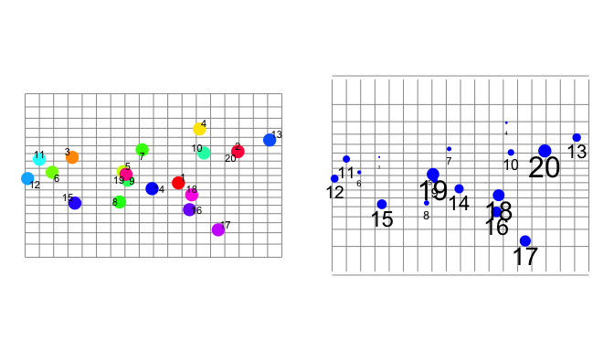

```r
par(mar=rep(1,4), mfrow=c(1,2))
map_proj("gall")  # use presets and set before projecting
x <- map_data(x)
map_setup(x)
map_grid()
map_points(x, col=rainbow(20), cex=2)
map_labels(x)

map_proj("mercator")  # use presets and set before projecting
x <- map_data(x)
map_setup(x)
map_grid()
map_points(x, col="blue", cex=1:20/10)
map_text(x, cex=1:20/10, pos=1)
```

### Superimposing

A simple form of projected convex hulls is implemented. Note that non-projected convex hulls can also be overlaid using, for example, the `convexhull` package from github.com/markheckmann/convexhull to draw non-projected convex hulls on top of the globe. In the following example two sets of points are enclosed by a hull.

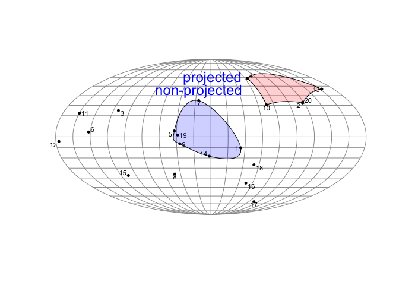

```r
library(convexhull)

map_proj("mollweide")  # use presets and set before projecting
x <- map_data(x)
map_setup(x)
map_grid()
map_points(x)
map_labels(x)
ii <- c(4,10,2, 20, 13)
map_convex_hull(x[ii, ], col="#FF000030")
map_text(x[4, ], label="projected", col="blue", cex=1.5, pos=2)

# standard non-projected convex hulls
pp <- c_proj(x)
ii <- c(1,5,7,9,14,19)
convex_hull(pp[ii, ], col="#0000FF30", smooth=2, shape = 2)
map_text(x[7, ], label="non-projected", col="blue", cex=1.5, pos=3)
```

### Subsetting

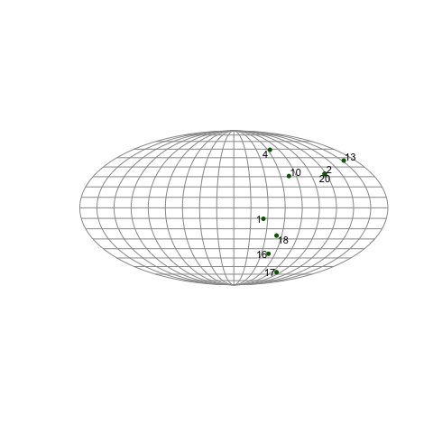

```r
map_setup(x)
map_grid()
map_points(x, "phi >= 0", col="darkgreen")
map_labels(x, "phi >= 0")
```

### Centroids

Add centroid using convenience wrappers.

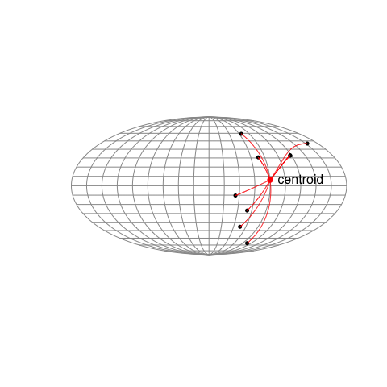

```r
map_setup(x)
map_grid()
ss <- .(phi >= 0)
map_points(x, ss)
map_centroid_point(x, ss, col="red")
map_centroid_star(x, ss, col="red")
map_centroid_label(x, "centroid", ss, pos=4)
```

Add a centroid point by hand using `centroid` to calculate its position.

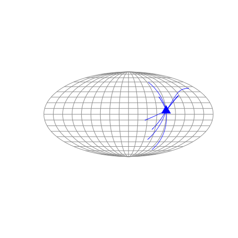

```r
map_setup(x)
map_grid()
c <- centroid(x, ss)                # calc centroid coordinates
map_points(c, cex=2, pch=17, col="blue")
s <- subset2(x, ss)    # select a subset of points
map_lines(s, c, col="blue")
```

## Internals

To prepare the coordinates, two functions are used internally.

`add_sphere_coords` takes the `x`, `y`, and `z` column and adds spherical coordinates `phi`, `theta`, `r`.

```r
x <- data.frame(x = runif(4),
                y = runif(4),
                z = runif(4))
x <- round(x, 1)
s <- add_sphere_coords(x)
s
```

```
#>     x   y   z      phi     theta         r
#> 1 1.0 0.6 0.4 30.96376 18.931823 1.2328828
#> 2 0.0 0.1 0.1 90.00000 45.000000 0.1414214
#> 3 0.6 0.6 0.1 45.00000  6.721369 0.8544004
#> 4 0.0 0.8 0.4 90.00000 26.565051 0.8944272
```

`add_proj_data` adds the projections in user coordinates `xp` and `yp` based on the spherical coords.

```r
s <- add_proj_data(s)
s
```

[output not shown]

The function `map_data` combines the two steps. This function is also called inside most functions to preprocess the data.

```r
s <- map_data(x)
s
```

[output not shown]

Convenience functions for extracting coordinates from the data.

```r
c_cart(s)
c_sphere(s)
c_proj(s)
```

[output not shown]